# Continuous Random Data

## Exponential distribution /Експоненциално разпределение/

**Exponential distribution** is the probability distribution of the time between events in a Poisson point process.
$$X \in Exp(\lambda)$$

**Cumulative distribution function (CDF)**
$$F_X(x) = 1 - e^{-\lambda x}, \quad x > 0$$
For $p \in (0, 1)$
$$1 - e^{-\lambda x} = p$$
$$1 - p = e^{-\lambda x}$$
$$ln(1 - p) = -\lambda x$$
$$x = -\frac{ln(1 - p)}{\lambda}$$
therefore

**Quantile function**
$$X_p = F_X^{\leftarrow}(p) = min\{x \in \mathbb{R} : P(X \leq x) \geq p\} = -\frac{ln(1 - p)}{\lambda}$$

**Probability density function (PDF)**
$$f_X(x) = \lambda e^{-\lambda x}, \quad x > 0$$

[figure not shown]

**Mean**
$$\mu = \frac{1}{\lambda}$$
**Variance**
$$\sigma^2 = \frac{1}{\lambda^2}$$

We can use the functions `dexp`, `rexp`, `pexp` and `qexp` to find the theoretical probability density function, to generate random numbers, to find the cumulative distribution function and quantiles of exponentially distributed random variable.

### Example

The average life of a bulb is $2$ years. Simulate the length of the life of $100$ bulbs and summarize the results.
$$X \in Exp \left( \frac{1}{2} \right)$$

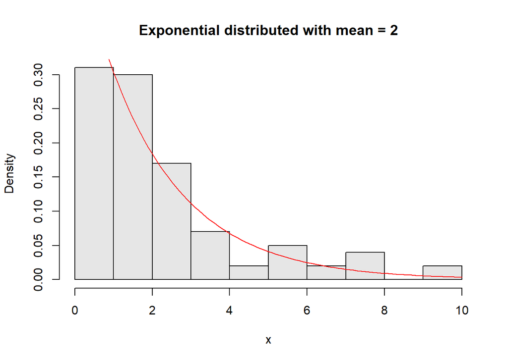

```r
> x <- rexp(100, 1/2)
> summary(x)
    Min.  1st Qu.   Median     Mean  3rd Qu.     Max.
0.004218 0.771401 1.568457 2.198680 2.897103 9.548184
> hist(x, probability = TRUE, col = gray(.9), main = "Exponential distributed with mean = 2")
> curve(dexp(x, 1/2), add = TRUE, col = "red")
```

We can calculate the skewness and kurtosis of the sample.

```r
> skewness(x)
[1] 1.595264
> kurtosis(x)
[1] 2.234495
```

As we can see the skewness is positive, because the exponential distribution is right-skewed. As far as the kurtosis is positive, the distribution is leptokurtic.

```r
> pexp(1.5, rate = 2)
[1] 0.9502129
```

```r
> pexp(1.5, rate = 2, lower.tail = FALSE)
[1] 0.04978707
```

$$P(X > 1.5) = 1 - P(X \leq 1.5)$$

```r
> 1 - pexp(1.5, rate = 2)
[1] 0.04978707
```

```r
> qexp(0.6, rate = 2)
[1] 0.4581454
```

## Gamma distribution /Гама разпределение/

**Gamma distribution** is a generalization of the exponential distribution.
$$X \in \Gamma(\alpha, \beta)$$

**Probability density function (PDF)** There are two parametrizations of **gamma distribution**. The first one is via the **rate parameter** $\beta > 0$. The second one is via the **scale parameter** $\theta = \frac{1}{\beta} > 0$.
$$f_X(x) = \frac{\beta^\alpha}{\Gamma(\alpha)} x^{\alpha-1} e^{-\beta x} = \frac{1}{\theta^\alpha \Gamma(\alpha)} x^{\alpha-1} e^{-\frac{x}{\theta}}, \quad x > 0$$
where
$$\Gamma(\alpha) = \int_{0}^{+\infty}{x^{\alpha-1} e^{-x} dx}, \quad \Gamma(n) = (n-1)!$$
and $\alpha > 0$ is called **shape parameter**.

[figure not shown]

$$\Gamma(1, \beta) \equiv Exp(\beta)$$

**Mean**
$$\mu = \frac{\alpha}{\beta}$$
**Variance**
$$\sigma^2 = \frac{\alpha}{\beta^2}$$

We can use the functions `dgamma`, `rgamma`, `pgamma` and `qgamma` to find the theoretical probability density function, to generate random numbers, to find the cumulative distribution function and quantiles of gamma distributed random variable.

### Example

The average life in years of a bulb is gamma distributed with shape parameter $5$ and rate parameter $3$. Simulate the length of the life of $100$ bulbs and summarize the results. Compute the expected length of the life and its variance.
$$X \in \Gamma(5, 3)$$

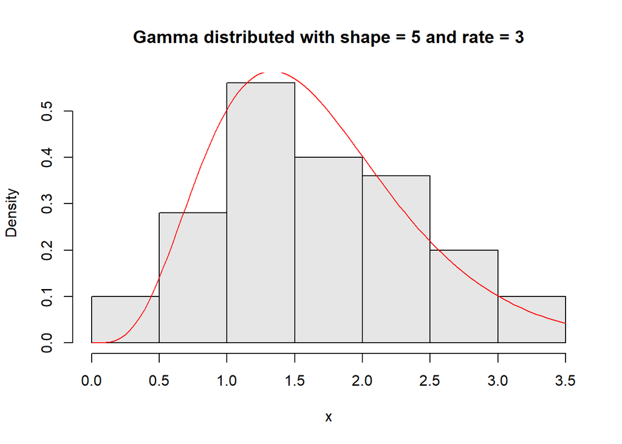

```r
> x <- rgamma(100, shape = 5, rate = 3)
> summary(x)
   Min. 1st Qu.  Median    Mean 3rd Qu.    Max.
 0.2271  1.0800  1.5388  1.6496  2.1403  3.3546
> hist(x, probability = TRUE, col = gray(.9), main = "Gamma distributed with shape = 5 and rate = 3")
> curve(dgamma(x, shape = 5, rate = 3), add = TRUE, col = "red")
```

$$E[X] = \frac{\alpha}{\beta} = \frac{5}{3} \approx 1.67$$
$$D[X] = \frac{\alpha}{\beta^2} = \frac{5}{3^2} \approx 0.56$$

```r
> var(x)
[1] 0.5181091
```

We can calculate the skewness and kurtosis of the sample.

```r
> skewness(x)
[1] 0.4217588
> kurtosis(x)
[1] -0.5214291
```

The theoretical probability a bulb to live less than or equal to $1.5$ years could be found by using the `pgamma` function.
$$P(X \leq 1.5)$$

```r
> pgamma(1.5, shape = 5, rate = 3)
[1] 0.4678964
```

A bulb to live more than $1.5$ years
$$P(X > 1.5)$$

```r
> pgamma(1.5, shape = 5, rate = 3, lower.tail = FALSE)
[1] 0.5321036
```

$$P(X > 1.5) = 1 - P(X \leq 1.5)$$

```r
> 1 - pgamma(1.5, shape = 5, rate = 3)
[1] 0.5321036
```

What is the $0.6$ quantile of this distribution or with other words what is the length of the life that will be reached by $60%$ of the bulbs.
$$X_{0.6} = min\{x \in \mathbb{R} : P(X \leq x) \geq 0.6\}$$

```r
> qgamma(0.6, shape = 5, rate = 3)
[1] 1.745539
```

## Normal distribution /Нормално разпределение/

The normal distribution is defined by the **Probability density function (PMF)** equation
$$f_X(x) = \frac{1}{\sigma \sqrt{2 \pi}} e^{-\frac{(x - \mu)^2}{2\sigma^2}}, \quad x \in \mathbb R$$

[figure not shown]

$$X \in N(\mu, \sigma^2)$$
**Mean**
$$\mu = E[X]$$
**Variance**
$$\sigma^2 = D[X]$$
We can use the functions `dnorm`, `rnorm`, `pnorm` and `qnorm` to find the theoretical probability density function, to generate random numbers, to find the cumulative distribution function and quantiles of normal distributed variable.

Let’s generate a realization of $N(100,16^2)$ random variable.

```r
> rnorm(1, mean = 100, sd = 16)
[1] 101.9347
```

```r
> rnorm(1, mean = 280, sd = 10)
[1] 281.8108
```

Let’s generate $1000$ realizations of $N(0,1^2)$ random variable.

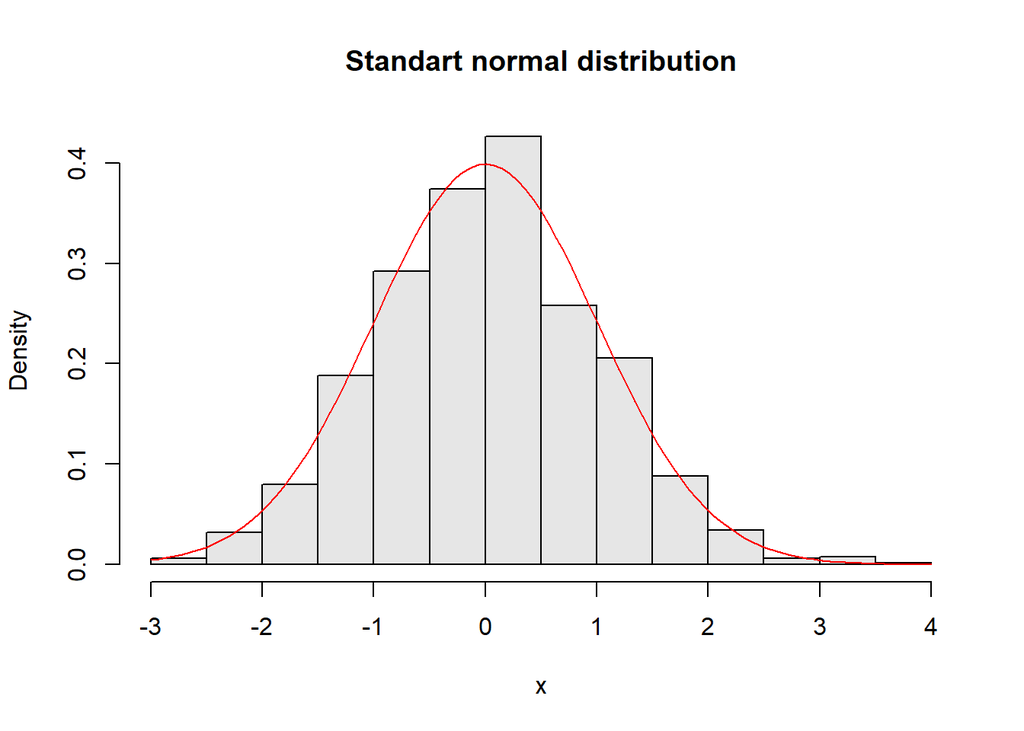

```r
> x <- rnorm(1000)
> hist(x, probability = TRUE, col = gray(.9), main = "Standart normal distribution")
> curve(dnorm(x), add = TRUE, col = "red")
```

Let’s generate $1000$ realizations of $N(100,16^2)$ random variable.

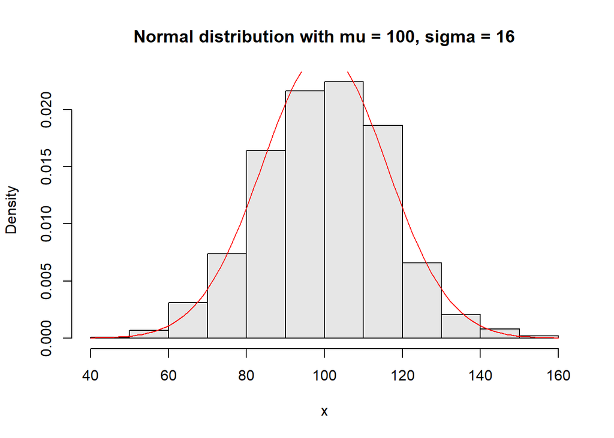

```r
> x <- rnorm(1000, mean = 100, sd = 16)
> hist(x, probability = TRUE, col = gray(.9), main = "Normal distribution with mu = 100, sigma = 16")
> curve(dnorm(x, mean = 100, sd = 16), add = TRUE, col = "red")
```

We can calculate the skewness and kurtosis of the sample.

```r
> skewness(x)
[1] -0.03903337
> kurtosis(x)
[1] 0.003985516
```

As we can see the skewness is approximately $0$, because the normal distribution is symmetric. As far as the kurtosis is almost $0$, the distribution is mesokurtic.

Let’s generate $1000$ realizations of $N(100,106^2)$ random variable.

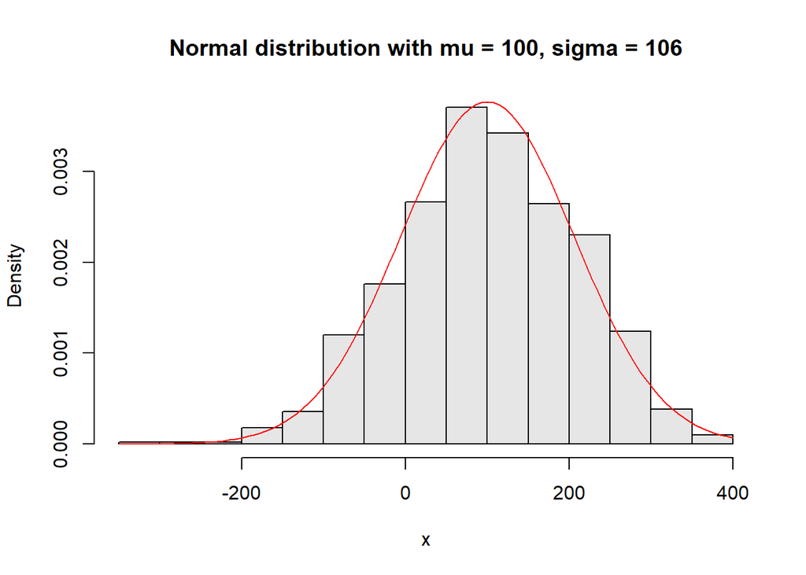

```r
> x <- rnorm(1000, mean = 100, sd = 106)
> hist(x, probability = TRUE, col = gray(.9), main = "Normal distribution with mu = 100, sigma = 106")
> curve(dnorm(x, mean = 100, sd = 106), add = TRUE, col = "red")
```

### z-scores

$$\text{Z-score}(x_i) = \frac{x_i - \mu}{\sigma}$$

```r
> mean.x <- 100; sd.x <- 16
> x <- rnorm(5, mean.x, sd.x); x
[1] 123.07510  70.83086  89.26677 120.52931 101.92490
> z.score = (x - mean.x) / sd.x; z.score
[1]  1.4421935 -1.8230714 -0.6708272  1.2830819  0.1203060
```

## Chi-squared distribution /Хи квадрат разпределение/

$$X \in \chi^2(n)$$
**Chi-squared distribution** is a particular case of gamma distribution. More precisely
$$\Gamma(\frac{n}{2}, \frac{1}{2}) \equiv \chi^2(n)$$

$\chi^2$ distribution with $n$ degrees of freedom is the distribution of a sum of the squares of $n$ independent standard normal variables
$$X_1, \: X_2, \: …, \: X_n \in N(0, 1) \: iid \: \Rightarrow X_1^2 + X_2^2 + ... + X_n^2 \in \chi^2(n)$$

[figure not shown]

**Mean**
$$\mu = n$$
**Variance**
$$\sigma^2 = 2n$$

We can use the functions `dchisq`, `rchisq`, `pchisq` and `qchisq` to find the theoretical probability density function, to generate random numbers, to find the cumulative distribution function and quantiles of chi-square distributed variable.

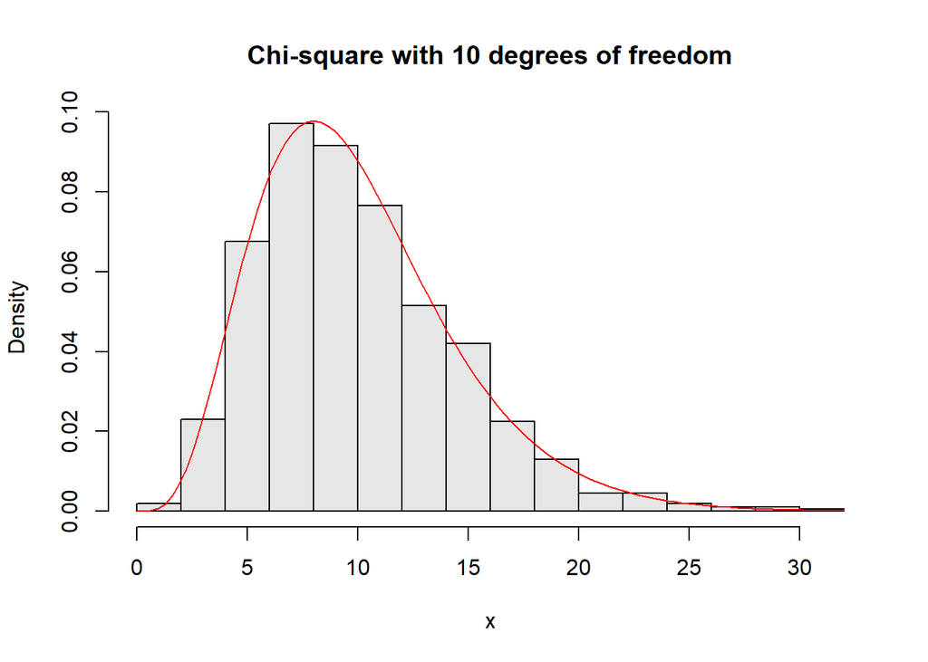

```r
> x <- rchisq(1000, 10)
> hist(x, probability = TRUE, col = gray(.9), main = "Chi-square with 10 degrees of freedom")
> curve(dchisq(x, 10), add = TRUE, col = "red")
```

We can calculate the skewness and kurtosis of the sample.

```r
> skewness(x)
[1] 0.9413891
> kurtosis(x)
[1] 1.217425
```

As we can see the skewness is positive, because the $\chi^2$ distribution is right-skewed. As far as the kurtosis is positive, the distribution is leptokurtic.

### Example:

```r
> pchisq(0.7, df = 5)
[1] 0.01703132
> pchisq(0.7, df = 5, lower.tail = FALSE)
[1] 0.9829687
> qchisq(0.75, df = 5)
[1] 6.62568
```

## Student’s t-distribution /t разпределение/

**Student’s t-distribution** was developed by **William Sealy Gosset** under the pseudonym Student. It can be used when the population proportion is normal and the sample size is under $30$.
$$X \in t(\nu)$$
Where $\nu = \text{sample size} - 1$ and is called **degrees of freedom**.

**Probability density function (PDF)**

[figure not shown]

**Mean**
$$\mu = 0$$
**Variance**
$$\sigma^2 = \frac{\nu}{\nu - 2}$$

We can use the functions `dt`, `rt`, `pt` and `qt` to find the theoretical probability density function, to generate random numbers, to find the cumulative distribution function and quantiles of student-t distributed variable.

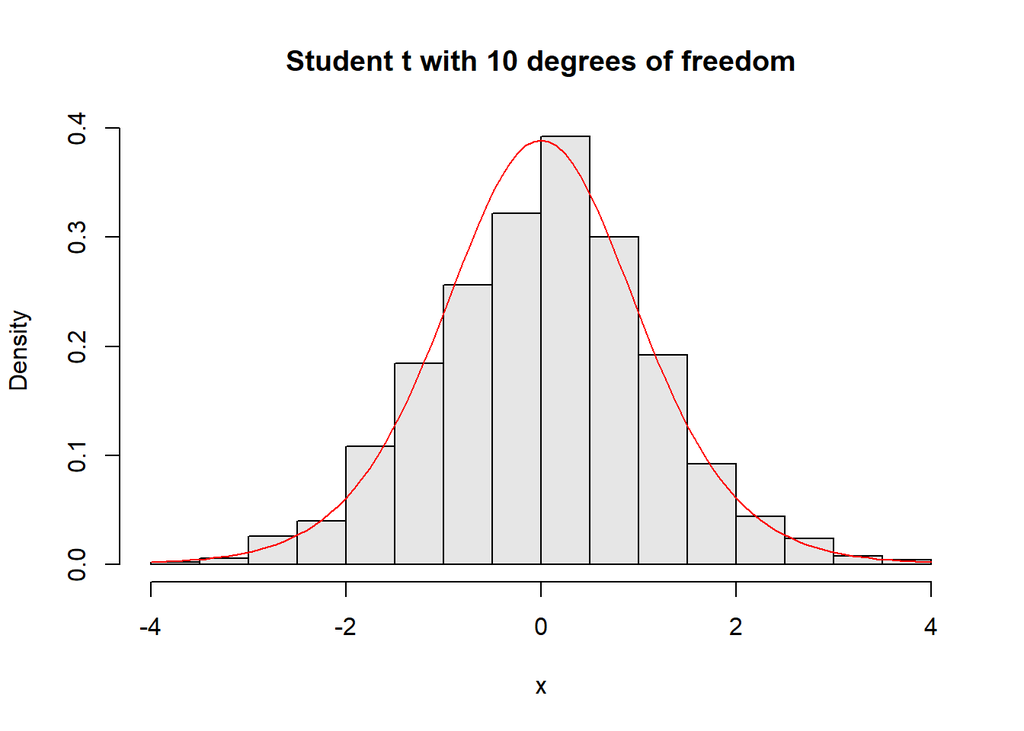

```r
> x <- rt(1000, 10)
> hist(x, probability = TRUE, col = gray(.9), main = "Student t with 10 degrees of freedom")
> curve(dt(x, 10), add = TRUE, col = "red")
```

We can calculate the skewness and kurtosis of the sample.

```r
> skewness(x)
[1] -0.04315149
> kurtosis(x)
[1] 0.2738327
```

As we can see the skewness is approximately $0$, because the student-t distribution is symmetric. As far as the kurtosis is positive, the distribution is leptokurtic.